# Natural Language Processing

```python
import nltk
```

```python
#nltk.download_shell() #Downloads stopwords Package
```

```python
#https://archive.ics.uci.edu/ml/datasets/SMS+Spam+Collection
```

```python
messages = [line.strip()
            for line in open(r'F:\DataScience_June2018\CourseMaterials\NaturalLanguageProcessing\smsspamcollection\SMSSpamCollection')]
```

```python
print(len(messages)) #Total Number of Messages
```

```
5574
```

```python
print(messages[0]) #First Message
```

```
ham	Go until jurong point, crazy.. Available only in bugis n great world la e buffet... Cine there got amore wat...
```

**Collection of text sometimes is called corpus**

```python
for mess_no, message in enumerate(messages[:10]):
    print(mess_no, message)
```

```
0 ham	Go until jurong point, crazy.. Available only in bugis n great world la e buffet... Cine there got amore wat...
1 ham	Ok lar... Joking wif u oni...
2 spam	Free entry in 2 a wkly comp to win FA Cup final tkts 21st May 2005. Text FA to 87121 to receive entry question(std txt rate)T&C's apply 08452810075over18's
3 ham	U dun say so early hor... U c already then say...
4 ham	Nah I don't think he goes to usf, he lives around here though
5 spam	FreeMsg Hey there darling it's been 3 week's now and no word back! I'd like some fun you up for it still? Tb ok! XxX std chgs to send, Â£1.50 to rcv
6 ham	Even my brother is not like to speak with me. They treat me like aids patent.
7 ham	As per your request 'Melle Melle (Oru Minnaminunginte Nurungu Vettam)' has been set as your callertune for all Callers. Press *9 to copy your friends Callertune
8 spam	WINNER!! As a valued network customer you have been selected to receivea Â£900 prize reward! To claim call 09061701461. Claim code KL341. Valid 12 hours only.
9 spam	Had your mobile 11 months or more? U R entitled to Update to the latest colour mobiles with camera for Free! Call The Mobile Update Co FREE on 08002986030
```

**Looking at the dataset, it looks like the file is tab separated and the first column is the label or target variable and the second column is the message itself.**

```python
import pandas as pd
```

```python
messages = pd.read_csv(r'F:\DataScience_June2018\CourseMaterials\NaturalLanguageProcessing\smsspamcollection\SMSSpamCollection', sep='\t',
                      names = ['label','message'])
```

```python
messages.head()
```

|  | label | message |
| --- | --- | --- |
| 0 | ham | Go until jurong point, crazy.. Available only ... |
| 1 | ham | Ok lar... Joking wif u oni... |
| 2 | spam | Free entry in 2 a wkly comp to win FA Cup fina... |
| 3 | ham | U dun say so early hor... U c already then say... |
| 4 | ham | Nah I don't think he goes to usf, he lives aro... |

### Exploratory Data Analysis (EDA)

```python
messages.describe()
```

|  | label | message |
| --- | --- | --- |
| count | 5572 | 5572 |
| unique | 2 | 5169 |
| top | ham | Sorry, I'll call later |
| freq | 4825 | 30 |

```python
messages.groupby('label').describe()
```

| label | message count | message unique | message top | message freq |
| --- | --- | --- | --- | --- |
| ham | 4825 | 4516 | Sorry, I'll call later | 30 |
| spam | 747 | 653 | Please call our customer service representativ... | 4 |

**Now we have to start thinking about the number of features or we call as feature engineering, better the knowledge about the data, better we will have the ability to feature the data.**

**Add one more column related to the length of the messages.**

```python
messages['length'] = messages['message'].apply(len)
```

```python
messages.head()
```

|  | label | message | length |
| --- | --- | --- | --- |
| 0 | ham | Go until jurong point, crazy.. Available only ... | 111 |
| 1 | ham | Ok lar... Joking wif u oni... | 29 |
| 2 | spam | Free entry in 2 a wkly comp to win FA Cup fina... | 155 |
| 3 | ham | U dun say so early hor... U c already then say... | 49 |
| 4 | ham | Nah I don't think he goes to usf, he lives aro... | 61 |

**Let's try to visualize**

```python
import matplotlib.pyplot as plt
import seaborn as sns
%matplotlib inline
```

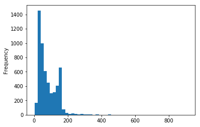

```python
messages['length'].plot.hist(bins=50)
```

```python
messages['length'].describe()
```

```
count    5572.000000
mean       80.489950
std        59.942907
min         2.000000
25%        36.000000
50%        62.000000
75%       122.000000
max       910.000000
Name: length, dtype: float64
```

**Looks like highest length size of the message is 910 characters**

**let's try to explore is the length of the message is the distinguish feature between spam and ham message**

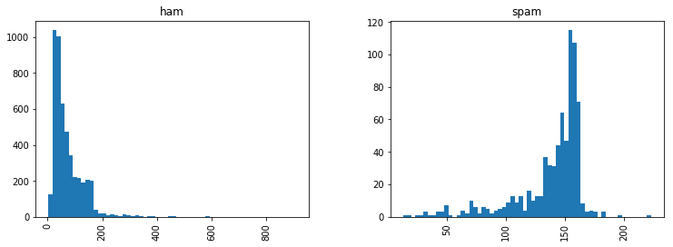

```python
messages.hist(column='length',by='label',bins=60,figsize=(12,4));
```

**Spam Messages has more number of characters as compared to Ham messages.**

**Let's do some Text Pre-Processing. If we neeed to do some classfication algorithm then we need some numerical vector values. In order to convert word into vector we will use Bag of words.**

```python
import string
```

**First, let's remove the punctuation and try on some sample message.**

```python
mess = 'Sample Message! Notice: it has punctuation.'
```

```python
string.punctuation
```

```
'!"#$%&\'()*+,-./:;<=>?@[\\]^_`{|}~'
```

```python
nopunc = [c for c in mess if c not in string.punctuation]
```

```python
from nltk.corpus import stopwords
```

```python
stopwords.words('english') #These words are so common, probably it won't be much helpful in order to predict about ham and spam.
```

```
['i',
 'me',
 'my',
 'myself',
 'we',
 'our',
 'ours',
 'ourselves',
 'you',
 "you're",
 "you've",
 "you'll",
 "you'd",
 'your',
 'yours',
 'yourself',
 'yourselves',
 'he',
 'him',
 'his',
 'himself',
 'she',
 "she's",
 'her',
 'hers',
 'herself',
 'it',
 "it's",
 'its',
 'itself',
 'they',
 'them',
 'their',
 'theirs',
 'themselves',
 'what',
 'which',
 'who',
 'whom',
 'this',
```

[output cut: 124 more lines]

```
 "mustn't",
 'needn',
 "needn't",
 'shan',
 "shan't",
 'shouldn',
 "shouldn't",
 'wasn',
 "wasn't",
 'weren',
 "weren't",
 'won',
 "won't",
 'wouldn',
 "wouldn't"]
```

```python
nopunc = "".join(nopunc)
nopunc
```

```
'Sample Message Notice it has punctuation'
```

```python
nopunc.split()
```

```
['Sample', 'Message', 'Notice', 'it', 'has', 'punctuation']
```

```python
clean_mess = [word for word in nopunc.split() if word.lower() not in stopwords.words('english')]
```

```python
clean_mess
```

```
['Sample', 'Message', 'Notice', 'punctuation']
```

```python
# Let's Apply the same to all the messages in the data frame
def text_process(mess):
    '''
    1. remove punctuation
    2. remove stop words
    3. return list of clean text words
    '''
    nopunc = [char for char in mess if char not in string.punctuation]
    nopunc = "".join(nopunc)
    return [word for word in nopunc.split() if word.lower() not in stopwords.words('english')]
```

```python
messages.head()
```

|  | label | message | length |
| --- | --- | --- | --- |
| 0 | ham | Go until jurong point, crazy.. Available only ... | 111 |
| 1 | ham | Ok lar... Joking wif u oni... | 29 |
| 2 | spam | Free entry in 2 a wkly comp to win FA Cup fina... | 155 |
| 3 | ham | U dun say so early hor... U c already then say... | 49 |
| 4 | ham | Nah I don't think he goes to usf, he lives aro... | 61 |

**let's tokenize the message**

```python
messages['message'].head(5).apply(text_process)
```

```
0    [Go, jurong, point, crazy, Available, bugis, n...
1                       [Ok, lar, Joking, wif, u, oni]
2    [Free, entry, 2, wkly, comp, win, FA, Cup, fin...
3        [U, dun, say, early, hor, U, c, already, say]
4    [Nah, dont, think, goes, usf, lives, around, t...
Name: message, dtype: object
```

Currently all the messages are as list of tokens and now we need to covert each of those messages into a vector the Scikit Learn's models can work with. we'll do that in three steps using bag-of-words model:

**1. Count how many times does a word occur in each message (known as term frequency).**

**2. Weigh the counts, so that frequent tokens get lower weight (inverse document frequency).**

**3. Normalize the vector to unit length, to abstract from the original text length (L2 norm).**

- Let's begin with the first step: *

**Each vector will have as many dimensions as there are unique words in the SMS corpus. We will use Scikit's Learn CountVectorizer. This model will convert a collection of text documents to a matrix of token counts.**

Since there are so many messages, we can expect a lot of zero counts for the presence of that word in that document. Beacuse of this, scikit learn will output a Sparse Matrix (https://en.wikipedia.org/wiki/Sparse_matrix)

```python
from sklearn.feature_extraction.text import CountVectorizer
```

```python
bow_transformer = CountVectorizer(analyzer=text_process).fit(messages['message'])
```

```python
print(len(bow_transformer.vocabulary_)) #Total number of unique words present
```

```
11425
```

```python
mess4 = messages['message'][3] #Grab the 4th message
print(mess4)
```

```
U dun say so early hor... U c already then say...
```

```python
bow4 = bow_transformer.transform([mess4])
```

```python
print(bow4) #It's appear there are 7 unique words present
```

```
  (0, 4068)	2
  (0, 4629)	1
  (0, 5261)	1
  (0, 6204)	1
  (0, 6222)	1
  (0, 7186)	1
  (0, 9554)	2
```

```python
print(bow4.shape)
```

```
(1, 11425)
```

```python
bow_transformer.get_feature_names()[4068]
```

```
'U'
```

```python
bow_transformer.get_feature_names()[9554]
```

```
'say'
```

```python
messages_bow = bow_transformer.transform(messages['message']) #Let's do the transform on complete dataframe
```

```python
print('Shape of Sparse Matrix', messages_bow.shape)
```

```
Shape of Sparse Matrix (5572, 11425)
```

```python
messages_bow.nnz #Non_zero Occurences
```

```
50548
```

**Weight and Normalization is done using TF-IDF**

```python
from sklearn.feature_extraction.text import TfidfTransformer
```

```python
tfidf_transformer = TfidfTransformer().fit(messages_bow)
```

```python
tfidf4 = tfidf_transformer.transform(bow4) #For Example - For the Fourth Message
```

```python
print(tfidf4) #weight values of each of the words
```

```
  (0, 9554)	0.5385626262927564
  (0, 7186)	0.4389365653379857
  (0, 6222)	0.3187216892949149
  (0, 6204)	0.29953799723697416
  (0, 5261)	0.29729957405868723
  (0, 4629)	0.26619801906087187
  (0, 4068)	0.40832589933384067
```

```python
messages_tfidf = tfidf_transformer.transform(messages_bow)
```

**Messages are finally converted to an vector**

```python
from sklearn.ensemble import RandomForestClassifier
```

```python
spam_detect_model = RandomForestClassifier().fit(messages_tfidf,messages['label'])
```

```python
spam_detect_model.predict(tfidf4)
```

```
array(['ham'], dtype=object)
```

```python
messages['label'][3]
```

```
'ham'
```

```python
all_pred = spam_detect_model.predict(messages_tfidf)
```

```python
all_pred
```

```
array(['ham', 'ham', 'spam', ..., 'ham', 'ham', 'ham'], dtype=object)
```

**Proper way to do is using train-test-split**

```python
from sklearn.model_selection import train_test_split
```

```python
msg_train, msg_test, label_train, label_test = train_test_split(messages['message'],messages['label'],test_size=0.3, random_state=42)
```

**Pipeline helps to save the complete workflow**

```python
from sklearn.pipeline import Pipeline
```

```python
pipeline = Pipeline([
    ('bow',CountVectorizer(analyzer=text_process)),
    ('tfidf', TfidfTransformer()),
    ('classifier',RandomForestClassifier())
])
```

```python
pipeline.fit(msg_train, label_train)
```

```
Pipeline(memory=None,
     steps=[('bow', CountVectorizer(analyzer=<function text_process at 0x000000000C12D620>,
        binary=False, decode_error='strict', dtype=<class 'numpy.int64'>,
        encoding='utf-8', input='content', lowercase=True, max_df=1.0,
        max_features=None, min_df=1, ngram_range=(1, 1), preprocesso...n_jobs=1,
            oob_score=False, random_state=None, verbose=0,
            warm_start=False))])
```

```python
predictions = pipeline.predict(msg_test)
```

```python
from sklearn.metrics import classification_report
```

```python
print(classification_report(label_test, predictions))
```

```
             precision    recall  f1-score   support

        ham       0.96      1.00      0.98      1448
       spam       1.00      0.73      0.84       224

avg / total       0.96      0.96      0.96      1672
```